# Supervised Learning Classification Project: AllLife Bank Personal Loan Campaign

## Problem Statement

### Context

AllLife Bank is a US bank that has a growing customer base. The majority of these customers are liability customers (depositors) with varying sizes of deposits. The number of customers who are also borrowers (asset customers) is quite small, and the bank is interested in expanding this base rapidly to bring in more loan business and in the process, earn more through the interest on loans. In particular, the management wants to explore ways of converting its liability customers to personal loan customers (while retaining them as depositors).

A campaign that the bank ran last year for liability customers showed a healthy conversion rate of over 9% success. This has encouraged the retail marketing department to devise campaigns with better target marketing to increase the success ratio.

You as a Data scientist at AllLife bank have to build a model that will help the marketing department to identify the potential customers who have a higher probability of purchasing the loan.

### Objective

To predict whether a liability customer will buy personal loans, to understand which customer attributes are most significant in driving purchases, and identify which segment of customers to target more.

### Data Dictionary

- `ID`: Customer ID
- `Age`: Customer’s age in completed years
- `Experience`: #years of professional experience
- `Income`: Annual income of the customer (in thousand dollars)
- `ZIP Code`: Home Address ZIP code.
- `Family`: the Family size of the customer
- `CCAvg`: Average spending on credit cards per month (in thousand dollars)
- `Education`: Education Level. 1: Undergrad; 2: Graduate;3: Advanced/Professional
- `Mortgage`: Value of house mortgage if any. (in thousand dollars)
- `Personal_Loan`: Did this customer accept the personal loan offered in the last campaign? (0: No, 1: Yes)
- `Securities_Account`: Does the customer have securities account with the bank? (0: No, 1: Yes)
- `CD_Account`: Does the customer have a certificate of deposit (CD) account with the bank? (0: No, 1: Yes)
- `Online`: Do customers use internet banking facilities? (0: No, 1: Yes)
- `CreditCard`: Does the customer use a credit card issued by any other Bank (excluding All life Bank)? (0: No, 1: Yes)

## Importing necessary libraries

```python
# import libraries for data manipulation
import numpy as np
import pandas as pd

import warnings
warnings.filterwarnings("ignore")  # ignore warnings

# import libraries for data visualization
import matplotlib.pyplot as plt
import seaborn as sns
import scipy.stats as stats
from sklearn import metrics, tree
from sklearn.tree import DecisionTreeClassifier
from sklearn.model_selection import train_test_split, GridSearchCV
from sklearn.metrics import (confusion_matrix, classification_report,
                             accuracy_score, precision_score, recall_score, f1_score)
import warnings
warnings.filterwarnings("ignore")  # ignore warnings

%matplotlib inline
sns.set()

%matplotlib inline
```

## Loading the dataset

```python
from google.colab import drive
drive.mount('/content/drive')
```

## Data Overview

- Observations
- Sanity checks

```python
# read the data
df = pd.read_csv('/content/drive/MyDrive/Loan_Modelling.csv')
# returns the first 5 rows
df.head()
```

|  | ID | Age | Experience | Income | ZIPCode | Family | CCAvg | Education | Mortgage | Personal_Loan | Securities_Account | CD_Account | Online | CreditCard |
| --- | --- | --- | --- | --- | --- | --- | --- | --- | --- | --- | --- | --- | --- | --- |
| 0 | 1 | 25 | 1 | 49 | 91107 | 4 | 1.6 | 1 | 0 | 0 | 1 | 0 | 0 | 0 |
| 1 | 2 | 45 | 19 | 34 | 90089 | 3 | 1.5 | 1 | 0 | 0 | 1 | 0 | 0 | 0 |
| 2 | 3 | 39 | 15 | 11 | 94720 | 1 | 1.0 | 1 | 0 | 0 | 0 | 0 | 0 | 0 |
| 3 | 4 | 35 | 9 | 100 | 94112 | 1 | 2.7 | 2 | 0 | 0 | 0 | 0 | 0 | 0 |
| 4 | 5 | 35 | 8 | 45 | 91330 | 4 | 1.0 | 2 | 0 | 0 | 0 | 0 | 0 | 1 |

```python
df.shape
```

```
(5000, 14)
```

```python
df.info()
```

```
<class 'pandas.core.frame.DataFrame'>
RangeIndex: 5000 entries, 0 to 4999
Data columns (total 14 columns):
 #   Column              Non-Null Count  Dtype
---  ------              --------------  -----
 0   ID                  5000 non-null   int64
 1   Age                 5000 non-null   int64
 2   Experience          5000 non-null   int64
 3   Income              5000 non-null   int64
 4   ZIPCode             5000 non-null   int64
 5   Family              5000 non-null   int64
 6   CCAvg               5000 non-null   float64
 7   Education           5000 non-null   int64
 8   Mortgage            5000 non-null   int64
 9   Personal_Loan       5000 non-null   int64
 10  Securities_Account  5000 non-null   int64
 11  CD_Account          5000 non-null   int64
 12  Online              5000 non-null   int64
 13  CreditCard          5000 non-null   int64
dtypes: float64(1), int64(13)
memory usage: 547.0 KB
```

```python
df.isnull().sum()
```

```
ID                    0
Age                   0
Experience            0
Income                0
ZIPCode               0
Family                0
CCAvg                 0
Education             0
Mortgage              0
Personal_Loan         0
Securities_Account    0
CD_Account            0
Online                0
CreditCard            0
dtype: int64
```

```python
df.describe(include = 'all').T
```

|  | count | mean | std | min | 25% | 50% | 75% | max |
| --- | --- | --- | --- | --- | --- | --- | --- | --- |
| ID | 5000.0 | 2500.500000 | 1443.520003 | 1.0 | 1250.75 | 2500.5 | 3750.25 | 5000.0 |
| Age | 5000.0 | 45.338400 | 11.463166 | 23.0 | 35.00 | 45.0 | 55.00 | 67.0 |
| Experience | 5000.0 | 20.104600 | 11.467954 | -3.0 | 10.00 | 20.0 | 30.00 | 43.0 |
| Income | 5000.0 | 73.774200 | 46.033729 | 8.0 | 39.00 | 64.0 | 98.00 | 224.0 |
| ZIPCode | 5000.0 | 93169.257000 | 1759.455086 | 90005.0 | 91911.00 | 93437.0 | 94608.00 | 96651.0 |
| Family | 5000.0 | 2.396400 | 1.147663 | 1.0 | 1.00 | 2.0 | 3.00 | 4.0 |
| CCAvg | 5000.0 | 1.937938 | 1.747659 | 0.0 | 0.70 | 1.5 | 2.50 | 10.0 |
| Education | 5000.0 | 1.881000 | 0.839869 | 1.0 | 1.00 | 2.0 | 3.00 | 3.0 |
| Mortgage | 5000.0 | 56.498800 | 101.713802 | 0.0 | 0.00 | 0.0 | 101.00 | 635.0 |
| Personal_Loan | 5000.0 | 0.096000 | 0.294621 | 0.0 | 0.00 | 0.0 | 0.00 | 1.0 |
| Securities_Account | 5000.0 | 0.104400 | 0.305809 | 0.0 | 0.00 | 0.0 | 0.00 | 1.0 |
| CD_Account | 5000.0 | 0.060400 | 0.238250 | 0.0 | 0.00 | 0.0 | 0.00 | 1.0 |
| Online | 5000.0 | 0.596800 | 0.490589 | 0.0 | 0.00 | 1.0 | 1.00 | 1.0 |
| CreditCard | 5000.0 | 0.294000 | 0.455637 | 0.0 | 0.00 | 0.0 | 1.00 | 1.0 |

## Exploratory Data Analysis.

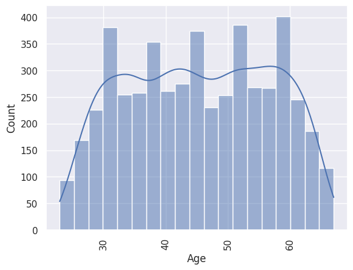

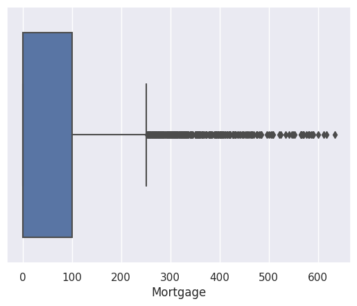

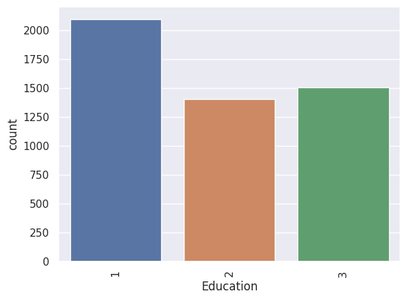

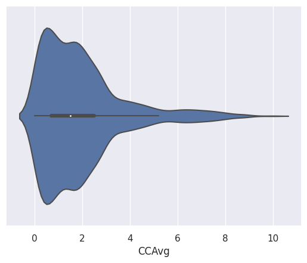

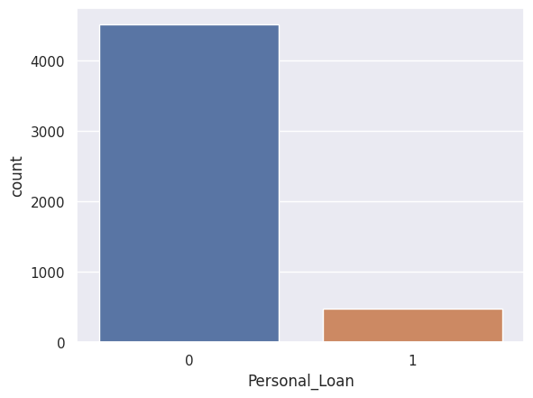

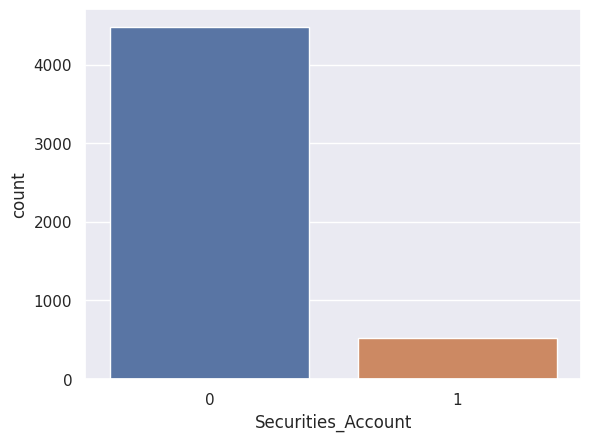

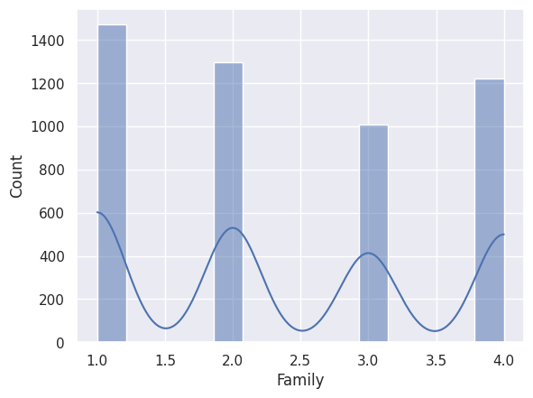

```python
sns.histplot(data = df, x = 'Age', kde = True)
plt.xticks(rotation = 90);
plt.show()
sns.boxplot(df, x = 'Mortgage')
plt.show()
sns.countplot(data = df, x = 'Education')
plt.xticks(rotation = 90);
plt.show()
sns.violinplot(data = df, x = 'CCAvg')
plt.show()
sns.countplot(data = df, x = 'Personal_Loan')
plt.show()
plt.show()
sns.countplot(data = df, x = 'Securities_Account')
plt.show()
sns.histplot(data = df, x = 'Family', kde = True)
plt.show()
plt.figure(figsize = (20,7))
```

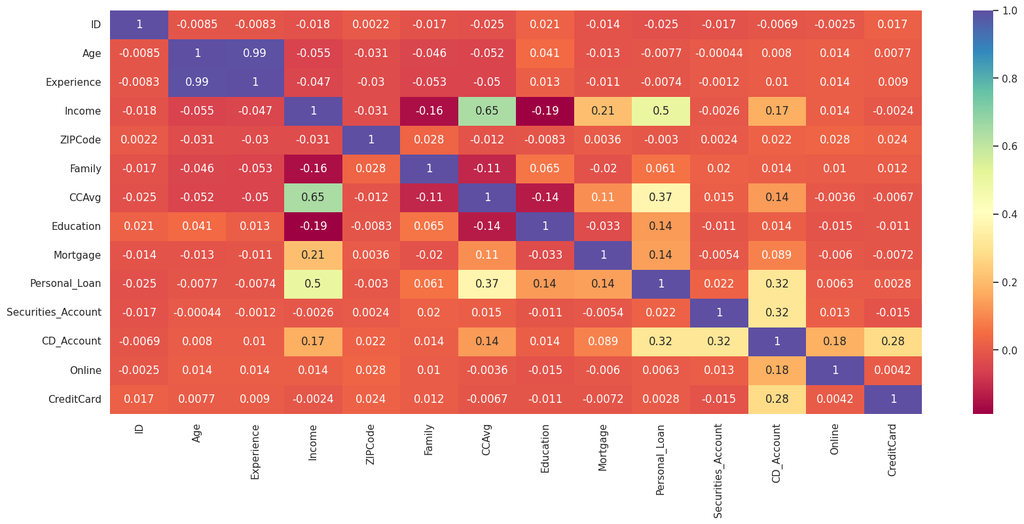

```python
plt.figure(figsize=(20, 8))
sns.heatmap(df.corr(), annot=True, cmap="Spectral");
```

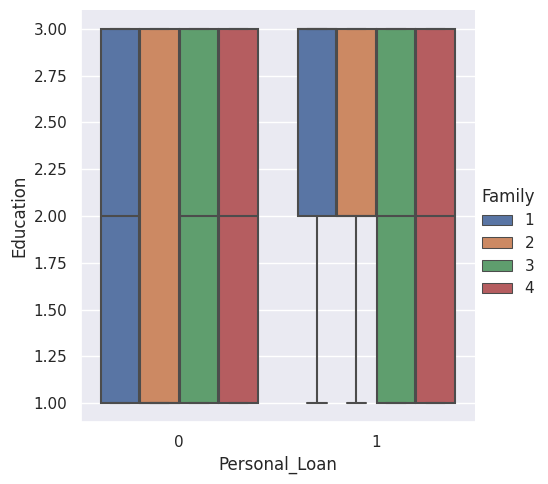

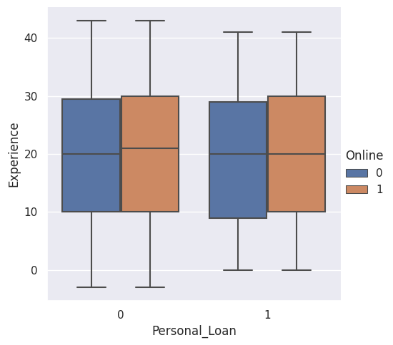

```python
sns.catplot(kind="box",data=df, y="Education",x = "Personal_Loan", hue="Family");
sns.catplot(data=df, kind="box", y="Experience", x= "Personal_Loan", hue="Online");
```

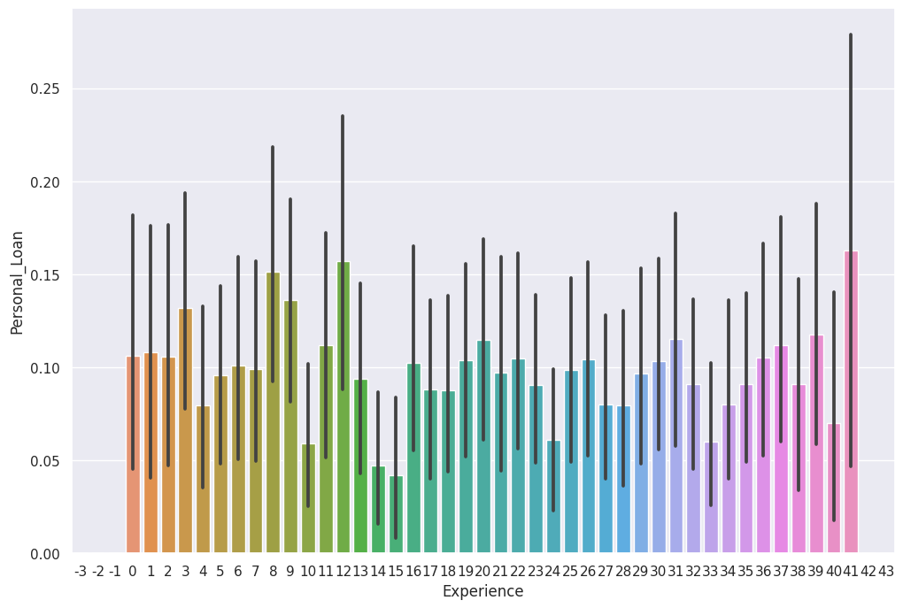

```python
plt.figure(figsize=(12, 8))
sns.barplot( data = df, x="Experience", y = 'Personal_Loan')
```

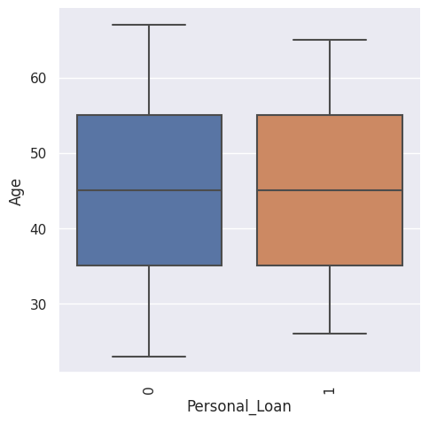

```python
sns.catplot(data=df, kind="box", x="Personal_Loan", y = "Age");
plt.xticks(rotation=90);
```

```
0    3530
1    1470
Name: CreditCard, dtype: int64
```

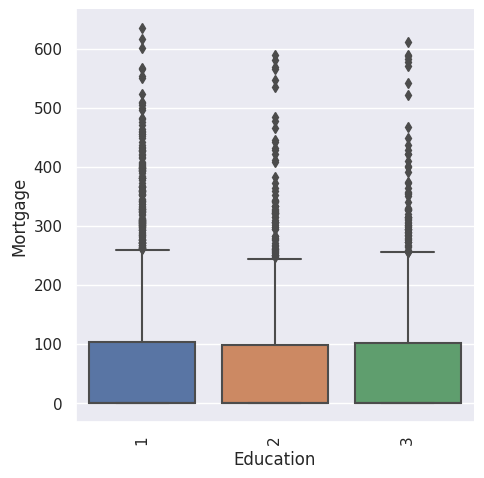

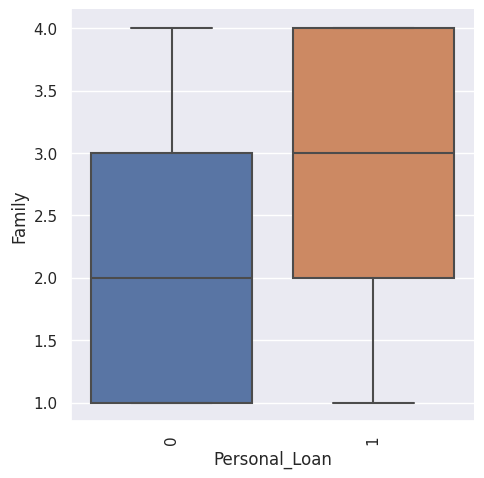

```python
credit_customer = df [["CreditCard"]].copy()
print (credit_customer["CreditCard"].value_counts())
sns.catplot(data=df, kind="box", x="Education", y = "Mortgage");
plt.xticks(rotation=90);
sns.catplot(data=df, kind="box", x="Personal_Loan", y = "Family");
plt.xticks(rotation=90);
```

## Personal loan and income have the next highest correlation of 0.5.

## Data Preprocessing

- Missing value treatment
- Feature engineering (if needed)
- Outlier detection and treatment (if needed)
- Preparing data for modeling
- Any other preprocessing steps (if needed)

```python
df.isnull().values.any()
```

```
False
```

```python
def featuress(feature1: str, feature2: str, data=df):
    crosstab = pd.crosstab(data[feature1], data[feature2])
    chi, p_value, dof, expected =  stats.chi2_contingency(crosstab)
    Ho = f"{feature1} -> no effect on {feature2}"
    Ha = f"{feature1}-> an effect on {feature2}"
    if p_value < 0.05:
        print(f'{Ha.upper()} as the p_value ({p_value.round(3)}) < 0.05')
    else:
        print(f'{Ho} as the p_value ({p_value.round(3)}) > 0.05')

def feature_chart(features: list, data=df):
    for feature in features:
        print("="*30, feature, "="*(50-len(feature)))
        for col in list(data.columns):
            if col != feature: featuress(col , feature)

feature_chart(['Personal_Loan', 'CD_Account'])
```

```
============================== Personal_Loan =====================================
ID -> no effect on Personal_Loan as the p_value (0.493) > 0.05
Age -> no effect on Personal_Loan as the p_value (0.12) > 0.05
Experience -> no effect on Personal_Loan as the p_value (0.704) > 0.05
INCOME-> AN EFFECT ON PERSONAL_LOAN as the p_value (0.0) < 0.05
ZIPCode -> no effect on Personal_Loan as the p_value (0.76) > 0.05
FAMILY-> AN EFFECT ON PERSONAL_LOAN as the p_value (0.0) < 0.05
CCAVG-> AN EFFECT ON PERSONAL_LOAN as the p_value (0.0) < 0.05
EDUCATION-> AN EFFECT ON PERSONAL_LOAN as the p_value (0.0) < 0.05
MORTGAGE-> AN EFFECT ON PERSONAL_LOAN as the p_value (0.0) < 0.05
Securities_Account -> no effect on Personal_Loan as the p_value (0.141) > 0.05
CD_ACCOUNT-> AN EFFECT ON PERSONAL_LOAN as the p_value (0.0) < 0.05
Online -> no effect on Personal_Loan as the p_value (0.693) > 0.05
CreditCard -> no effect on Personal_Loan as the p_value (0.884) > 0.05
============================== CD_Account ========================================
ID -> no effect on CD_Account as the p_value (0.493) > 0.05
AGE-> AN EFFECT ON CD_ACCOUNT as the p_value (0.027) < 0.05
Experience -> no effect on CD_Account as the p_value (0.086) > 0.05
INCOME-> AN EFFECT ON CD_ACCOUNT as the p_value (0.0) < 0.05
ZIPCode -> no effect on CD_Account as the p_value (0.675) > 0.05
FAMILY-> AN EFFECT ON CD_ACCOUNT as the p_value (0.018) < 0.05
CCAVG-> AN EFFECT ON CD_ACCOUNT as the p_value (0.0) < 0.05
Education -> no effect on CD_Account as the p_value (0.58) > 0.05
MORTGAGE-> AN EFFECT ON CD_ACCOUNT as the p_value (0.0) < 0.05
PERSONAL_LOAN-> AN EFFECT ON CD_ACCOUNT as the p_value (0.0) < 0.05
SECURITIES_ACCOUNT-> AN EFFECT ON CD_ACCOUNT as the p_value (0.0) < 0.05
ONLINE-> AN EFFECT ON CD_ACCOUNT as the p_value (0.0) < 0.05
CREDITCARD-> AN EFFECT ON CD_ACCOUNT as the p_value (0.0) < 0.05
```

## Model Building

```python
df_dummies = pd.get_dummies(df, columns=['Education', 'Family'], drop_first=True)
df_dummies.head()
```

|  | ID | Age | Experience | Income | ZIPCode | CCAvg | Mortgage | Personal_Loan | Securities_Account | CD_Account | Online | CreditCard | Education_2 | Education_3 | Family_2 | Family_3 | Family_4 |
| --- | --- | --- | --- | --- | --- | --- | --- | --- | --- | --- | --- | --- | --- | --- | --- | --- | --- |
| 0 | 1 | 25 | 1 | 49 | 91107 | 1.6 | 0 | 0 | 1 | 0 | 0 | 0 | 0 | 0 | 0 | 0 | 1 |
| 1 | 2 | 45 | 19 | 34 | 90089 | 1.5 | 0 | 0 | 1 | 0 | 0 | 0 | 0 | 0 | 0 | 1 | 0 |
| 2 | 3 | 39 | 15 | 11 | 94720 | 1.0 | 0 | 0 | 0 | 0 | 0 | 0 | 0 | 0 | 0 | 0 | 0 |
| 3 | 4 | 35 | 9 | 100 | 94112 | 2.7 | 0 | 0 | 0 | 0 | 0 | 0 | 1 | 0 | 0 | 0 | 0 |
| 4 | 5 | 35 | 8 | 45 | 91330 | 1.0 | 0 | 0 | 0 | 0 | 0 | 1 | 1 | 0 | 0 | 0 | 1 |

```python
df_dummies.info()
```

```
<class 'pandas.core.frame.DataFrame'>
RangeIndex: 5000 entries, 0 to 4999
Data columns (total 17 columns):
 #   Column              Non-Null Count  Dtype
---  ------              --------------  -----
 0   ID                  5000 non-null   int64
 1   Age                 5000 non-null   int64
 2   Experience          5000 non-null   int64
 3   Income              5000 non-null   int64
 4   ZIPCode             5000 non-null   int64
 5   CCAvg               5000 non-null   float64
 6   Mortgage            5000 non-null   int64
 7   Personal_Loan       5000 non-null   int64
 8   Securities_Account  5000 non-null   int64
 9   CD_Account          5000 non-null   int64
 10  Online              5000 non-null   int64
 11  CreditCard          5000 non-null   int64
 12  Education_2         5000 non-null   uint8
 13  Education_3         5000 non-null   uint8
 14  Family_2            5000 non-null   uint8
 15  Family_3            5000 non-null   uint8
 16  Family_4            5000 non-null   uint8
dtypes: float64(1), int64(11), uint8(5)
memory usage: 493.3 KB
```

```python
X = df_dummies.drop(['Personal_Loan'], axis=1)
X.head(5)
```

|  | ID | Age | Experience | Income | ZIPCode | CCAvg | Mortgage | Securities_Account | CD_Account | Online | CreditCard | Education_2 | Education_3 | Family_2 | Family_3 | Family_4 |
| --- | --- | --- | --- | --- | --- | --- | --- | --- | --- | --- | --- | --- | --- | --- | --- | --- |
| 0 | 1 | 25 | 1 | 49 | 91107 | 1.6 | 0 | 1 | 0 | 0 | 0 | 0 | 0 | 0 | 0 | 1 |
| 1 | 2 | 45 | 19 | 34 | 90089 | 1.5 | 0 | 1 | 0 | 0 | 0 | 0 | 0 | 0 | 1 | 0 |
| 2 | 3 | 39 | 15 | 11 | 94720 | 1.0 | 0 | 0 | 0 | 0 | 0 | 0 | 0 | 0 | 0 | 0 |
| 3 | 4 | 35 | 9 | 100 | 94112 | 2.7 | 0 | 0 | 0 | 0 | 0 | 1 | 0 | 0 | 0 | 0 |
| 4 | 5 | 35 | 8 | 45 | 91330 | 1.0 | 0 | 0 | 0 | 0 | 1 | 1 | 0 | 0 | 0 | 1 |

```python
y = df_dummies['Personal_Loan']
y.head(5)
```

```
0    0
1    0
2    0
3    0
4    0
Name: Personal_Loan, dtype: int64
```

```python
X_train, X_test, y_train, y_test = train_test_split(X, y, test_size=0.3, random_state=1)
```

INITIAL MODEL

```python
mod = DecisionTreeClassifier(criterion='gini',
                               class_weight={0:0.15, 1:0.85},
                               random_state=1)
mod.fit(X_train, y_train)
```

```
DecisionTreeClassifier(class_weight={0: 0.15, 1: 0.85}, random_state=1)
```

```python
print(tree.export_text(mod,feature_names=feature_names,show_weights=True))
```

[output not shown]

[output cut: 153 more lines]

```
|   |   |   |   |   |   |   |   |   |--- weights: [0.00, 1.70] class: 1
|   |   |   |   |   |   |   |--- Income >  99.50
|   |   |   |   |   |   |   |   |--- weights: [0.00, 11.05] class: 1
|   |   |   |   |   |   |--- CD_Account >  0.50
|   |   |   |   |   |   |   |--- Experience <= 21.00
|   |   |   |   |   |   |   |   |--- weights: [0.30, 0.00] class: 0
|   |   |   |   |   |   |   |--- Experience >  21.00
|   |   |   |   |   |   |   |   |--- weights: [0.00, 0.85] class: 1
|   |   |   |   |   |--- ID >  4852.50
|   |   |   |   |   |   |--- weights: [0.15, 0.00] class: 0
|   |   |--- Income >  116.50
|   |   |   |--- ID <= 13.50
|   |   |   |   |--- weights: [0.00, 0.85] class: 1
|   |   |   |--- ID >  13.50
|   |   |   |   |--- weights: [0.00, 96.05] class: 1
```

```python
def confusion_matrix( model, y_actual, labels=[1, 0], xtest=X_test):
    y_predict = model.predict(xtest)
    cm = metrics.confusion_matrix(y_actual, y_predict, labels=[0, 1])
    df_cm = pd.DataFrame(cm, index=["Actual - No","Actual - Yes"],
                         columns=['Predicted - No','Predicted - Yes'])


    group_counts = [f"{value:0.0f}" for value in cm.flatten()]
    group_percentages = [f"{value:.2%}" for value in cm.flatten()/np.sum(cm)]

    labels = [f"{gc}\n{gp}" for gc, gp in zip(group_counts, group_percentages)]
    labels = np.asarray(labels).reshape(2,2)


    sns.heatmap(df_cm, annot=labels, fmt='')
    plt.ylabel('True label', fontsize=14)
    plt.xlabel('Predicted label', fontsize=14);
```

[figure not shown]

```python
confusion_matrix(model, y_test)
```

```python
y_train.value_counts(normalize=True)
```

```
0    0.905429
1    0.094571
Name: Personal_Loan, dtype: float64
```

BASELINE MODEL DECISION TREE

```python
feature_names = list(X.columns)
print(feature_names)
```

```
['ID', 'Age', 'Experience', 'Income', 'ZIPCode', 'CCAvg', 'Mortgage', 'Securities_Account', 'CD_Account', 'Online', 'CreditCard', 'Education_2', 'Education_3', 'Family_2', 'Family_3', 'Family_4']
```

[figure not shown]

```python
plt.figure(figsize=(20, 30))
out = tree.plot_tree(mod,
                     feature_names=feature_names,
                     filled=True,
                     fontsize=9,
                     node_ids=False,
                     class_names=None,)
for i in out:
     arrow = i.arrow_patch
     if arrow is not None:
        arrow.set_edgecolor('black')
        arrow.set_linewidth(1)
plt.show()
```

### Model Performance Improvement

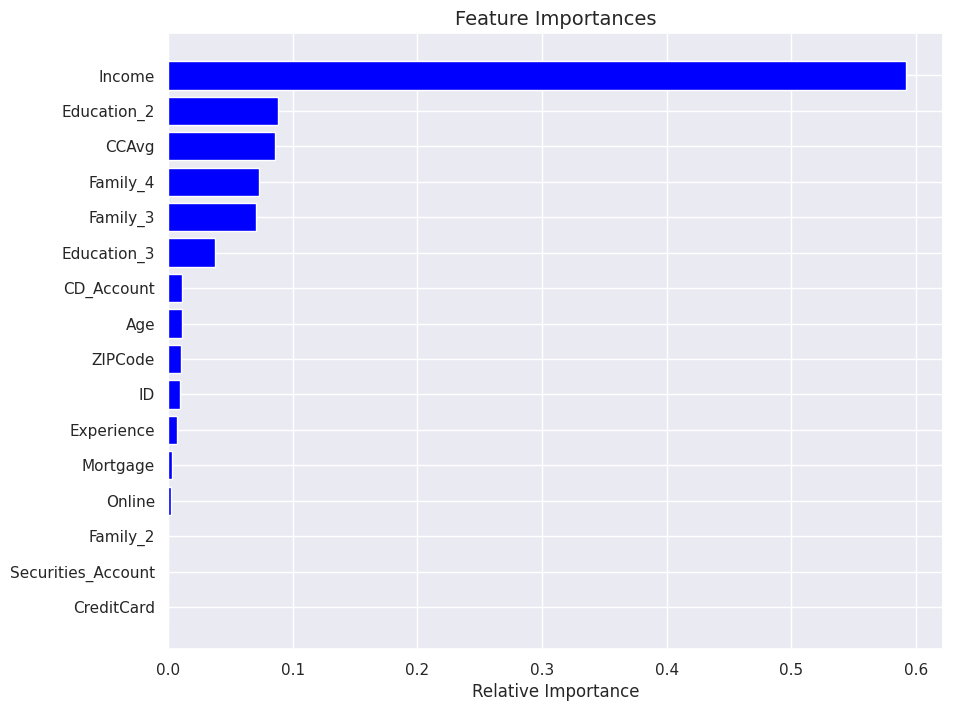

```python
def imp_plot(model):

    importances = model.feature_importances_
    indices = np.argsort(importances)
    size = len(indices)//2

    plt.figure(figsize=(10, size))
    plt.title("Feature Importances", fontsize=14)
    plt.barh(range(len(indices)), importances[indices], color='blue', align='center')
    plt.yticks(range(len(indices)), [feature_names[i] for i in indices])
    plt.xlabel("Relative Importance", fontsize=12);
imp_plot(mod)
```

```python
pd.DataFrame(mod.feature_importances_,
                   columns=["Imp"],
                   index=X_train.columns).sort_values(by='Imp', ascending=False)
```

|  | Imp |
| --- | --- |
| Income | 5.925077e-01 |
| Education_2 | 8.813411e-02 |
| CCAvg | 8.563040e-02 |
| Family_4 | 7.261065e-02 |
| Family_3 | 7.032437e-02 |
| Education_3 | 3.713789e-02 |
| CD_Account | 1.133793e-02 |
| Age | 1.092303e-02 |
| ZIPCode | 1.047472e-02 |
| ID | 8.985089e-03 |
| Experience | 7.040014e-03 |
| Mortgage | 2.947456e-03 |
| Online | 1.946623e-03 |
| Family_2 | 9.799370e-18 |
| Securities_Account | 1.601820e-18 |
| CreditCard | 0.000000e+00 |

USING GRIDSEARCH

```python
estimator = DecisionTreeClassifier(random_state=1, class_weight={0:.15,1:.85})
parameters = {'max_depth': np.arange(1,10),
              'criterion': ['entropy','gini'],
              'splitter': ['best','random'],
              'min_impurity_decrease': [0.000001,0.00001,0.0001],
              'max_features': ['log2','sqrt']}

scorer = metrics.make_scorer(metrics.recall_score)
grid_obj = GridSearchCV(estimator, param_grid=parameters, scoring=scorer, cv=5)
grid_obj = grid_obj.fit(X_train, y_train)

estimator = grid_obj.best_estimator_

estimator.fit(X_train, y_train)
```

```
DecisionTreeClassifier(class_weight={0: 0.15, 1: 0.85}, criterion='entropy',
                       max_depth=3, max_features='log2',
                       min_impurity_decrease=1e-06, random_state=1,
                       splitter='random')
```

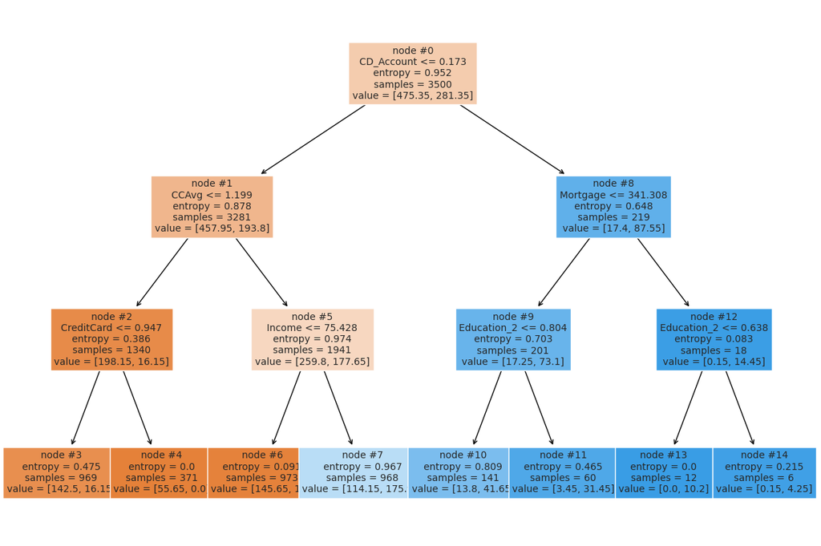

```python
plt.figure(figsize=(15, 10))
out = tree.plot_tree(estimator,
                     feature_names=feature_names,
                     filled=True,
                     fontsize=10,
                     node_ids=True,
                     class_names=None)
for i in out:
    arrow = i.arrow_patch
    if arrow is not None:
        arrow.set_edgecolor('black')
        arrow.set_linewidth(1)
plt.show()
```

```python
print(tree.export_text(estimator,
                       feature_names=feature_names,
                       show_weights=True))
```

```
|--- CD_Account <= 0.17
|   |--- CCAvg <= 1.20
|   |   |--- CreditCard <= 0.95
|   |   |   |--- weights: [142.50, 16.15] class: 0
|   |   |--- CreditCard >  0.95
|   |   |   |--- weights: [55.65, 0.00] class: 0
|   |--- CCAvg >  1.20
|   |   |--- Income <= 75.43
|   |   |   |--- weights: [145.65, 1.70] class: 0
|   |   |--- Income >  75.43
|   |   |   |--- weights: [114.15, 175.95] class: 1
|--- CD_Account >  0.17
|   |--- Mortgage <= 341.31
|   |   |--- Education_2 <= 0.80
|   |   |   |--- weights: [13.80, 41.65] class: 1
|   |   |--- Education_2 >  0.80
|   |   |   |--- weights: [3.45, 31.45] class: 1
|   |--- Mortgage >  341.31
|   |   |--- Education_2 <= 0.64
|   |   |   |--- weights: [0.00, 10.20] class: 1
|   |   |--- Education_2 >  0.64
|   |   |   |--- weights: [0.15, 4.25] class: 1
```

```python
cf = DecisionTreeClassifier(random_state=1, class_weight = {0:0.15, 1:0.85})
path = cf.cost_complexity_pruning_path(X_train, y_train)
ccp_alphas, impurities = path.ccp_alphas, path.impurities
```

```python
cfs = []
for ccp_alpha in ccp_alphas:
    cf = DecisionTreeClassifier(random_state=1,
                                 ccp_alpha=ccp_alpha,
                                 class_weight = {0:0.15,1:0.85})
    cf.fit(X_train, y_train)
    cfs.append(cf)

print(f"Last tree has number of nodes: {cfs[-1].tree_.node_count} with ccp_alpha: {ccp_alphas[-1]}")
```

```
Last tree has number of nodes: 1 with ccp_alpha: 0.25379571489480973
```

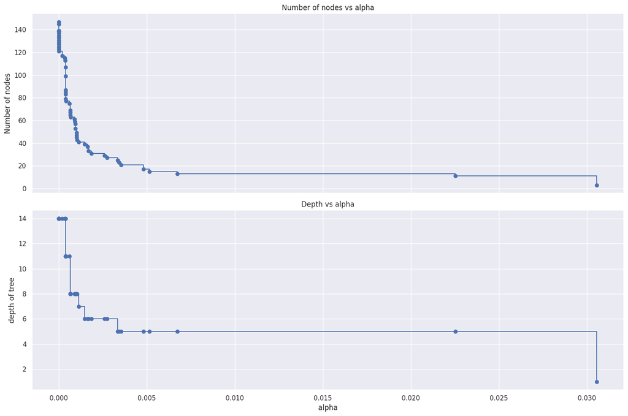

```python
cfs = cfs[:-1]
ccp_alphas = ccp_alphas[:-1]

node_counts = [cf.tree_.node_count for cf in cfs]
depth = [cf.tree_.max_depth for cf in cfs]
fig, ax = plt.subplots(2, 1, figsize=(15, 10), sharex=True)
ax[0].plot(ccp_alphas, node_counts, marker='o', drawstyle="steps-post")
ax[0].set_ylabel("Number of nodes")
ax[0].set_title("Number of nodes vs alpha")
ax[1].plot(ccp_alphas, depth, marker='o', drawstyle="steps-post")
ax[1].set_xlabel("alpha")
ax[1].set_ylabel("depth of tree")
ax[1].set_title("Depth vs alpha")
fig.tight_layout()
```